# distributions_and_correlation_analyses

The purpose of this code is to simulate medical data with heavy-tailed characteristics using a t-Copula to generate correlated variables (such as Glucose, Cholesterol, BMI, and Blood Pressure).

We model the data using a **Multivariate t-Distribution** and apply a t-Copula to introduce correlations, ensuring that the generated dataset aligns with the statistical properties of real-world medical data.

```r
library(tidyverse)
library(MASS)
library(Matrix)
library(copula)
library(mvtnorm)   # For multivariate t-distribution
library(ggplot2)
library(GGally)
library(DT)

set.seed(123)

# Define parameters
nu <- 5  # Degrees of freedom (controls tail thickness)
p <- 4   # Number of variables

# Define mean vector
mu <- c(100,   # Mean Glucose Level (mg/dL)
        200,   # Mean Cholesterol Level (mg/dL)
        25,    # Mean BMI (Body Mass Index)
        120)   # Mean Blood Pressure (mmHg)
```

1. Degrees of Freedom *(nu = 5)* A lower degrees of freedom (e.g., 5) results in a heavier tail, which better simulates extreme cases in medical data, such as patients with diabetes or obesity.  
   Higher degrees of freedom make the data closer to a normal distribution, but medical data is often non-normal, making the t-distribution a better fit.
2. Number of Variables *(p = 4)*  
   These four variables (Glucose, Cholesterol, BMI, Blood Pressure) are commonly used metabolic and cardiovascular health indicators.  
   In real-world data, these variables often exhibit correlations, making them suitable for a correlation-based simulation.
3. Choice of Mean Values *(mu)*  
   The mean values are set based on realistic medical data:  
   *Glucose:* Typically ranges from 70-140 mg/dL, so setting the mean to 100 mg/dL is reasonable.  
   *Cholesterol:* A normal range is 150-250 mg/dL, making 200 mg/dL a suitable average.  
   *BMI:* Normal BMI falls between 18-30, so 25 is a standard mean.  
   *Blood Pressure:* Healthy blood pressure ranges from 90-140 mmHg, making 120 mmHg an appropriate mean.

```r
# Define block structures
# Block-diagonal: high correlation within groups, no correlation across groups
# Glucose & Cholesterol (Metabolism)
block1 <- matrix(c(1, 0.5,
                   0.5, 1), nrow=2, ncol=2)
# BMI & Blood Pressure (Cardiovascular)
block2 <- matrix(c(1, 0.4,
                   0.4, 1), nrow=2, ncol=2)

# Combine blocks into a block-diagonal matrix
Sigma <- bdiag(block1, block2)

# Convert to a standard matrix format
# Ensure the correlation matrix is positive definite
Sigma <- as.matrix(nearPD(Sigma)$mat)
```

A **block-diagonal correlation structure** is chosen to reflect real-world physiological relationships in medical data, ensuring that highly related variables are grouped together while unrelated ones remain independent.

Medical Justification for Grouping Variables:

1. Glucose & Cholesterol (Metabolic Block)  
   These two variables are often correlated because they are both regulated by insulin and metabolic processes.  
   Patients with high glucose levels (e.g., in diabetes) often have elevated cholesterol due to metabolic dysfunction.
2. BMI & Blood Pressure (Cardiovascular Block)  
   Higher BMI is strongly associated with increased blood pressure, as obesity contributes to hypertension and cardiovascular disease.  
   This correlation reflects real-world epidemiological findings in obesity and hypertension studies.

```r
# Extract lower triangle correlations
rho_vec <- Sigma[lower.tri(Sigma)]

# Define the t-Copula
copula_t <- tCopula(param=rho_vec, dim=p, df=nu, dispstr="un")

# Generate Copula-Based Uniform Samples
U_t <- rCopula(1000, copula_t)

# Generate Independent Heavy-Tailed t-Distributions
# Use scale() to avoid the variance might be too high for a realistic medical dataset
glucose <- scale(rt(1000, df=nu)) * 15 + mu[1]
cholesterol <- scale(rt(1000, df=nu)) * 25 + mu[2]
BMI <- scale(rt(1000, df=nu)) * 3 + mu[3]
blood_pressure <- scale(rt(1000, df=nu)) * 10 + mu[4]

# Map Copula Uniform Samples Back to Heavy-Tailed t-Distributions
data_copula_t <- data.frame(
  Glucose = quantile(glucose, probs = U_t[,1]),
  Cholesterol = quantile(cholesterol, probs = U_t[,2]),
  BMI = quantile(BMI, probs = U_t[,3]),
  BloodPressure = quantile(blood_pressure, probs = U_t[,4])
)

# Generate correlation matrix
corr_matrix <- cor(data_copula_t) %>% as.data.frame()
knitr::kable(corr_matrix, caption = "Correlation Matrix of t_copula", digits = 3)
```

Correlation Matrix of t_copula

|  | Glucose | Cholesterol | BMI | BloodPressure |
| --- | --- | --- | --- | --- |
| Glucose | 1.000 | 0.411 | -0.071 | 0.041 |
| Cholesterol | 0.411 | 1.000 | -0.028 | -0.039 |
| BMI | -0.071 | -0.028 | 1.000 | 0.390 |
| BloodPressure | 0.041 | -0.039 | 0.390 | 1.000 |

A t-Copula is ideal for modeling correlated medical data with heavy tails, capturing realistic dependencies between variables.

Medical variables (glucose, cholesterol, BMI, blood pressure) often show heavy-tailed distributions.  
The t-Copula ensures that extreme values tend to co-occur, reflecting real-world patterns (e.g., high glucose & high cholesterol in diabetes).

A Gaussian Copula assumes weak tail dependence, failing to model joint extremes properly.

Correlation Matrix Interpretation

[output not shown]

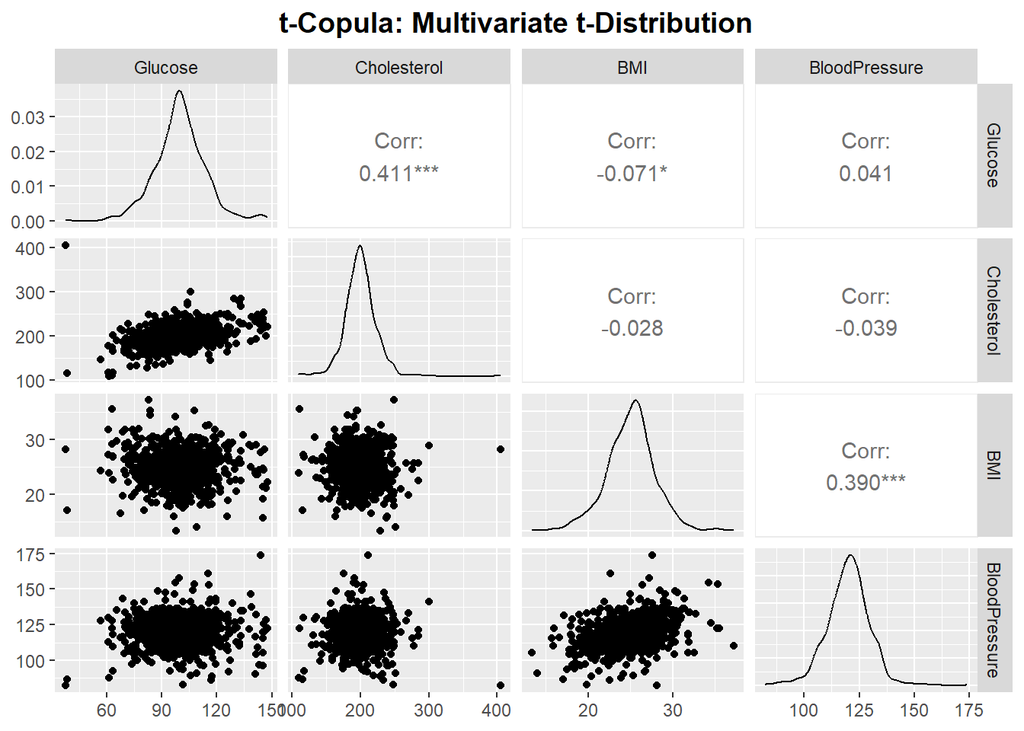

```r
ggpairs(data_copula_t,
        title = "t-Copula: Multivariate t-Distribution",
        lower = list(continuous = "points"),
        diag = list(continuous = "densityDiag"),
        upper = list(continuous = "cor")) +
  theme(plot.title = element_text(hjust = 0.5, face="bold", size=14))
```

```r
# Generate multivariate t-distributed data
n <- 1000  # Number of samples

# Generate multivariate t-distribution data
data_t <- rmvt(n=n, sigma=Sigma, df=nu) + matrix(mu, nrow=n, ncol=length(mu), byrow=TRUE)  # matrix format, add mu row-wise
data_t <- as.data.frame(data_t) |>
  setNames(c("Glucose", "Cholesterol", "BMI", "BloodPressure"))
```

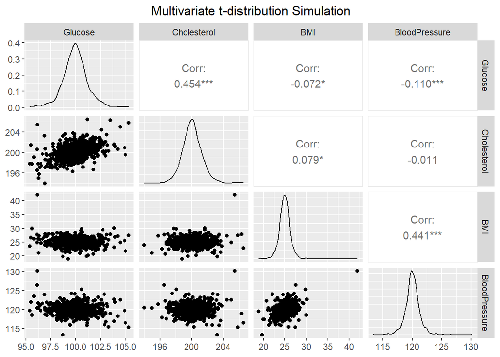

```r
ggpairs(data_t, title="Multivariate t-distribution Simulation") +  # Scatterplot matrix for all variables
  theme(plot.title = element_text(hjust = 0.5))
```